# Parametric Survival Models Report

Model Fitting and Validation Results for METIMMOX-1

Author

Health Economics Analysis

Published

October 8, 2025

# 1 Executive Summary

This report presents the results of parametric survival model fitting for the METIMMOX-1 health economic analysis. The models compare different biomarker strategies for overall survival (OS) and progression-free survival (PFS) outcomes, providing essential inputs for the cost-effectiveness analysis.

# 2 Setup and Data Loading

# 3 Model Specifications and Reference Values

## 3.1 Population Characteristics

```r
if (exists("ref_age") && exists("predictions")) {

  # Create reference values table
  ref_table <- data.frame(
    Variable = c("Age (years)", "Sex", "CRP", "TLR", "TMB_BRAF"),
    Value = c(
      paste(round(ref_age, 1), "(mean)"),
      paste(ref_sex, "(0=female, 1=male)"),
      paste(ref_crp, "(0=negative, 1=positive)"),
      paste(ref_tlr, "(0=negative, 1=positive)"),
      paste(ref_tmb_braf, "(0=negative, 1=positive)")
    ),
    Description = c(
      "Mean age in complete cases",
      "Modal sex category",
      "Modal CRP status",
      "Modal TLR status",
      "Modal TMB_BRAF status"
    )
  )

  kable(ref_table, format = "html") %>%
    kableExtra::kable_styling(bootstrap_options = c("striped", "hover"))

} else {
  cat("Reference values not available. Run main analysis first.\n")
}
```

Table 1: Reference values used for population predictions

| Variable | Value | Description |
| --- | --- | --- |
| Age (years) | 64 (mean) | Mean age in complete cases |
| Sex | 1 (0=female, 1=male) | Modal sex category |
| CRP | 0 (0=negative, 1=positive) | Modal CRP status |
| TLR | 1 (0=negative, 1=positive) | Modal TLR status |
| TMB_BRAF | 0 (0=negative, 1=positive) | Modal TMB_BRAF status |

## 3.2 Biomarker Prevalences

```r
if (exists("strategies_df")) {

  biomarker_table <- strategies_df %>%
    filter(id != "control") %>%
    mutate(
      Biomarker = toupper(id),
      `Prevalence (%)` = round(prevalence * 100, 1),
      `Sample Size` = paste0("n=", round(prevalence * nrow(data_complete)))
    ) %>%
    select(Biomarker, `Prevalence (%)`, `Sample Size`)

  kable(biomarker_table, format = "html") %>%
    kableExtra::kable_styling(bootstrap_options = c("striped", "hover"))

  cat("\n**Data completeness:**", nrow(data_complete), "of", nrow(data),
      "observations (", round(nrow(data_complete)/nrow(data) * 100, 1), "%)\n")
}
```

```
**Data completeness:** 65 of 74 observations ( 87.8 %)
```

# 4 Model Selection and Comparison

## 4.1 Information Criteria Comparison

The model selection is based on Akaike Information Criterion (AIC), which is more appropriate for predictive modeling compared to BIC. AIC balances model fit with complexity, while BIC tends to select overly simple models that might miss important biomarker interactions.

```r
if (exists("models") && !is.null(models$full)) {

  # Overall Survival models
  cat("### Overall Survival (OS) Models\n\n")

  os_comparison <- rbind(
    data.frame(Structure = "Full Model", models$full$os_ic),
    data.frame(Structure = "No Age/Sex", models$no_age_sex$os_ic)
  ) %>%
    arrange(AIC) %>%
    mutate(
      AIC = round(AIC, 2),
      BIC = round(BIC, 2),
      `Delta AIC` = round(AIC - min(AIC, na.rm = TRUE), 2),
      Rank = rank(AIC, na.last = "keep")
    )

  # Mark best model
  if (exists("models") && !is.null(models$best_fit$os_aic)) {
    best_idx <- which.min(abs(os_comparison$AIC - models$best_fit$os_aic))
    if (length(best_idx) > 0) {
      os_comparison$Selected <- ""
      os_comparison$Selected[best_idx] <- "⭐"
    }
  }

  DT::datatable(os_comparison,
                options = list(pageLength = 10, dom = 't'),
                rownames = FALSE) %>%
    DT::formatStyle(columns = "Selected", fontWeight = "bold")

  cat("\n\n### Progression-Free Survival (PFS) Models\n\n")

  # Progression-Free Survival models
  pfs_comparison <- rbind(
    data.frame(Structure = "Full Model", models$full$pfs_ic),
    data.frame(Structure = "No Age/Sex", models$no_age_sex$pfs_ic)
  ) %>%
    arrange(AIC) %>%
    mutate(
      AIC = round(AIC, 2),
      BIC = round(BIC, 2),
      `Delta AIC` = round(AIC - min(AIC, na.rm = TRUE), 2),
      Rank = rank(AIC, na.last = "keep")
    )

  # Mark best model
  if (exists("models") && !is.null(models$best_fit$pfs_aic)) {
    best_idx <- which.min(abs(pfs_comparison$AIC - models$best_fit$pfs_aic))
    if (length(best_idx) > 0) {
      pfs_comparison$Selected <- ""
      pfs_comparison$Selected[best_idx] <- "⭐"
    }
  }

  DT::datatable(pfs_comparison,
                options = list(pageLength = 10, dom = 't'),
                rownames = FALSE) %>%
    DT::formatStyle(columns = "Selected", fontWeight = "bold")

} else {
  cat("Model comparison tables not available.\n")
}
```

```
### Overall Survival (OS) Models



### Progression-Free Survival (PFS) Models
```

Table 3: Model comparison using AIC and BIC

| Structure | Distribution | AIC | BIC | Delta AIC | Rank | Selected |
| --- | --- | --- | --- | --- | --- | --- |
| No Age/Sex | gamma | 450.06 | 469.62 | 0 | 1 | ⭐ |
| No Age/Sex | lognormal | 450.21 | 469.78 | 0.15 | 2 |  |
| No Age/Sex | weibullph | 450.62 | 470.19 | 0.56 | 3.5 |  |
| No Age/Sex | weibull | 450.62 | 470.19 | 0.56 | 3.5 |  |
| No Age/Sex | gengamma | 451.98 | 473.72 | 1.92 | 5 |  |
| No Age/Sex | llogis | 452.49 | 472.06 | 2.43 | 6 |  |
| Full Model | gamma | 453.43 | 477.35 | 3.37 | 7 |  |
| Full Model | lognormal | 453.46 | 477.38 | 3.4 | 8 |  |
| No Age/Sex | genf | 453.98 | 477.9 | 3.92 | 9 |  |
| Full Model | weibull | 454.19 | 478.11 | 4.13 | 10.5 |  |

[output cut: 8 more lines]

# 5 Population Survival Curves

## 5.1 Overall Survival Models

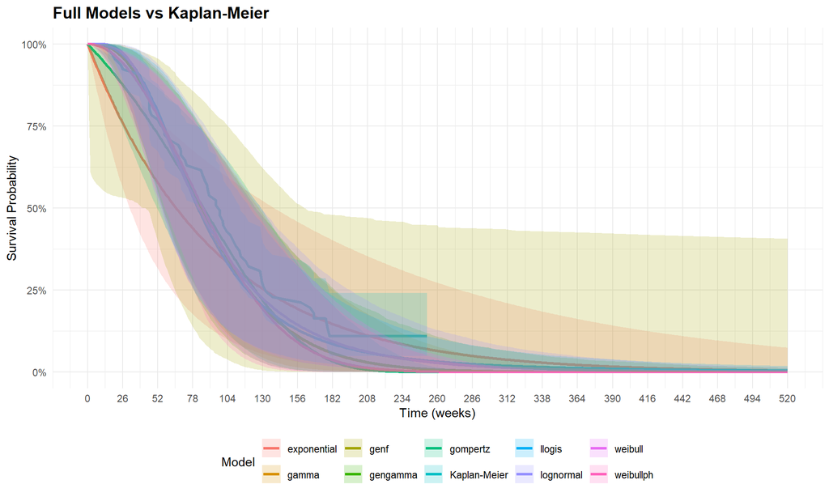

(a) Full models (including age and sex)

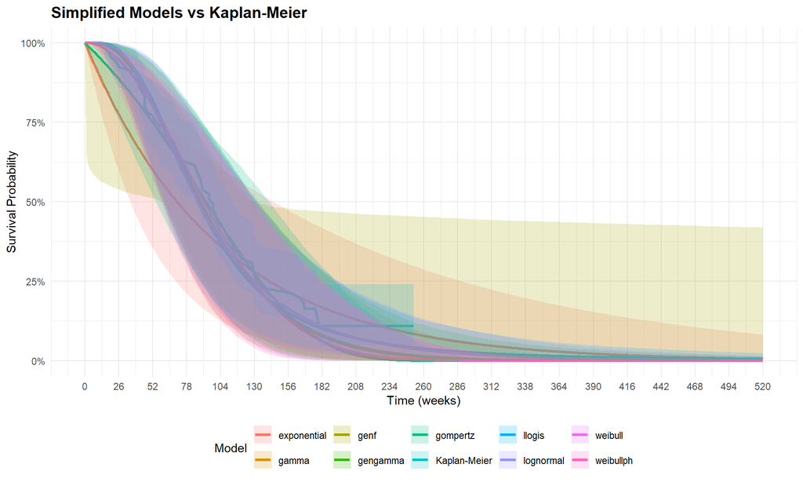

(b) Simplified models (biomarkers only)

Figure 1: Overall survival curves comparing parametric models with Kaplan-Meier estimates

```r
if (exists("models") && exists("data_complete")) {

  # OS curves - full models
  os_full_data <- create_population_plots(models, data_complete, time_points, "OS")
  os_full_data <- os_full_data[os_full_data$structure %in% c("Observed", "full"), ]

  if (nrow(os_full_data) > 0) {
    p_os_full <- ggplot(os_full_data, aes(x = time, y = survival, color = model)) +
      geom_line(linewidth = 1.2) +
      geom_ribbon(aes(ymin = lower, ymax = upper, fill = model), alpha = 0.2, color = NA) +
      scale_y_continuous(limits = c(0, 1), labels = scales::percent) +
      scale_x_continuous(breaks = seq(0, max(time_points), by = 26)) +
      labs(title = "Full Models vs Kaplan-Meier",
           x = "Time (weeks)", y = "Survival Probability",
           color = "Model", fill = "Model") +
      theme(legend.position = "bottom")

    print(p_os_full)
  }

  # OS curves - no age/sex models
  os_simple_data <- create_population_plots(models, data_complete, time_points, "OS")
  os_simple_data <- os_simple_data[os_simple_data$structure %in% c("Observed", "no_age_sex"), ]

  if (nrow(os_simple_data) > 0) {
    p_os_simple <- ggplot(os_simple_data, aes(x = time, y = survival, color = model)) +
      geom_line(linewidth = 1.2) +
      geom_ribbon(aes(ymin = lower, ymax = upper, fill = model), alpha = 0.2, color = NA) +
      scale_y_continuous(limits = c(0, 1), labels = scales::percent) +
      scale_x_continuous(breaks = seq(0, max(time_points), by = 26)) +
      labs(title = "Simplified Models vs Kaplan-Meier",
           x = "Time (weeks)", y = "Survival Probability",
           color = "Model", fill = "Model") +
      theme(legend.position = "bottom")

    print(p_os_simple)
  }
}
```

## 5.2 Progression-Free Survival Models

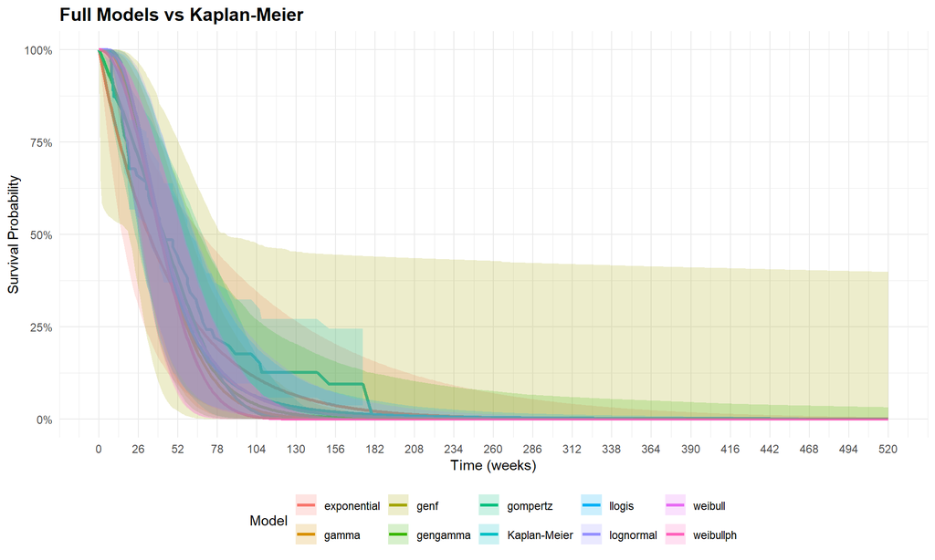

(a) Full models (including age and sex)

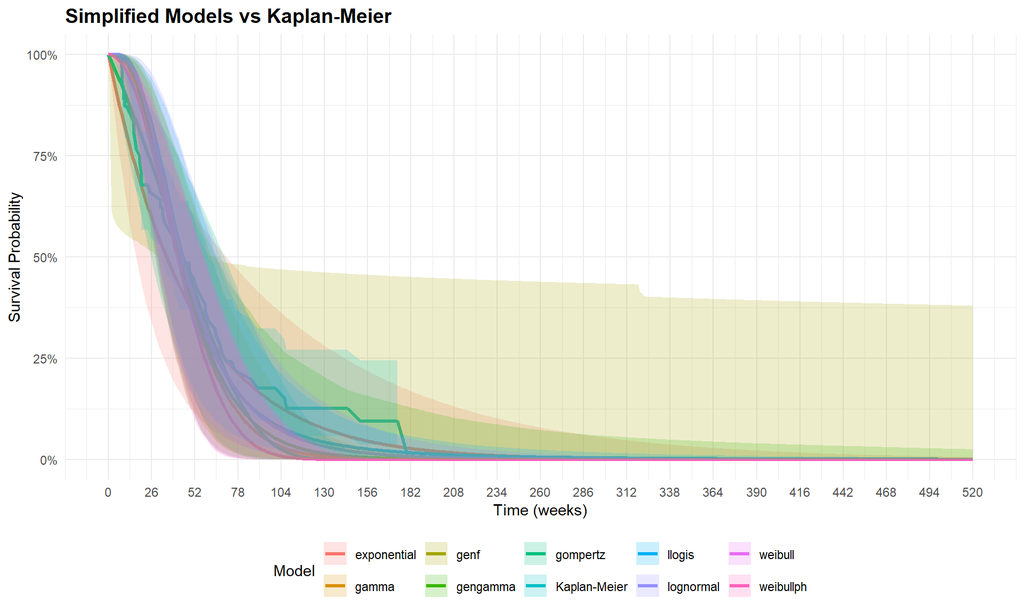

(b) Simplified models (biomarkers only)

Figure 2: Progression-free survival curves comparing parametric models with Kaplan-Meier estimates

```r
if (exists("models") && exists("data_complete")) {

  # PFS curves - full models
  pfs_full_data <- create_population_plots(models, data_complete, time_points, "PFS")
  pfs_full_data <- pfs_full_data[pfs_full_data$structure %in% c("Observed", "full"), ]

  if (nrow(pfs_full_data) > 0) {
    p_pfs_full <- ggplot(pfs_full_data, aes(x = time, y = survival, color = model)) +
      geom_line(linewidth = 1.2) +
      geom_ribbon(aes(ymin = lower, ymax = upper, fill = model), alpha = 0.2, color = NA) +
      scale_y_continuous(limits = c(0, 1), labels = scales::percent) +
      scale_x_continuous(breaks = seq(0, max(time_points), by = 26)) +
      labs(title = "Full Models vs Kaplan-Meier",
           x = "Time (weeks)", y = "Survival Probability",
           color = "Model", fill = "Model") +
      theme(legend.position = "bottom")

    print(p_pfs_full)
  }

  # PFS curves - no age/sex models
  pfs_simple_data <- create_population_plots(models, data_complete, time_points, "PFS")
  pfs_simple_data <- pfs_simple_data[pfs_simple_data$structure %in% c("Observed", "no_age_sex"), ]

  if (nrow(pfs_simple_data) > 0) {
    p_pfs_simple <- ggplot(pfs_simple_data, aes(x = time, y = survival, color = model)) +
      geom_line(linewidth = 1.2) +
      geom_ribbon(aes(ymin = lower, ymax = upper, fill = model), alpha = 0.2, color = NA) +
      scale_y_continuous(limits = c(0, 1), labels = scales::percent) +
      scale_x_continuous(breaks = seq(0, max(time_points), by = 26)) +
      labs(title = "Simplified Models vs Kaplan-Meier",
           x = "Time (weeks)", y = "Survival Probability",
           color = "Model", fill = "Model") +
      theme(legend.position = "bottom")

    print(p_pfs_simple)
  }
}
```

# 6 Biomarker-Specific Results

```
##  CRP  Biomarker Results
```

```
##  TLR  Biomarker Results
```

```
##  TMB_BRAF  Biomarker Results
```

[figure not shown]

Figure 3: Biomarker-specific survival curves

[figure not shown]

Figure 4: Biomarker-specific survival curves

[figure not shown]

Figure 5: Biomarker-specific survival curves

[figure not shown]

Figure 6: Biomarker-specific survival curves

[figure not shown]

Figure 7: Biomarker-specific survival curves

[figure not shown]

Figure 8: Biomarker-specific survival curves

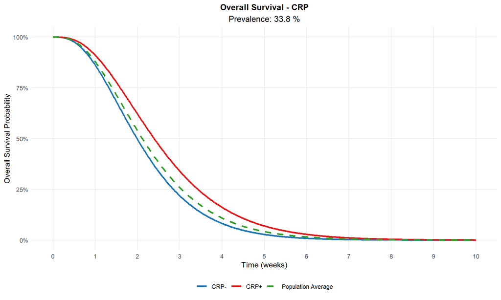

Figure 9: Biomarker-specific survival curves

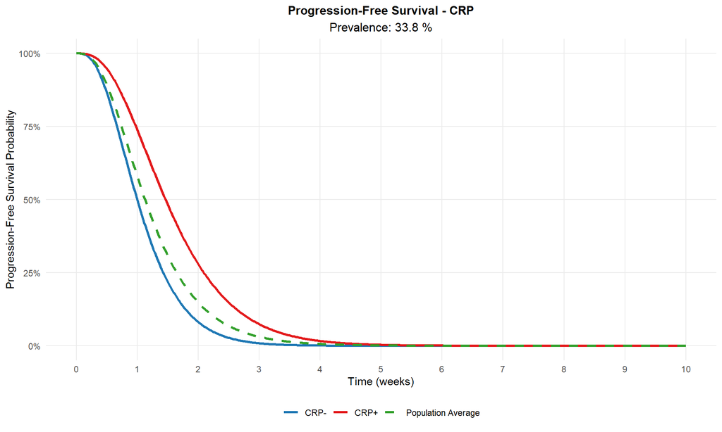

Figure 10: Biomarker-specific survival curves

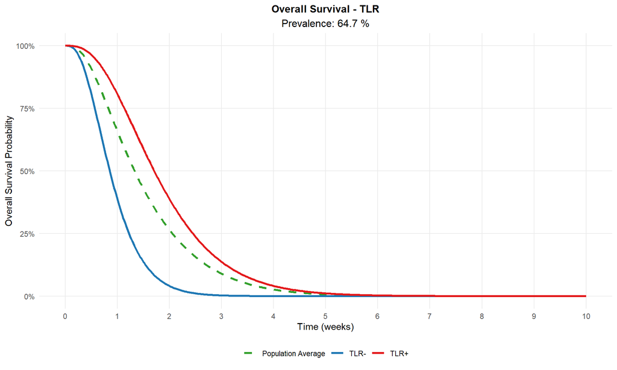

Figure 11: Biomarker-specific survival curves

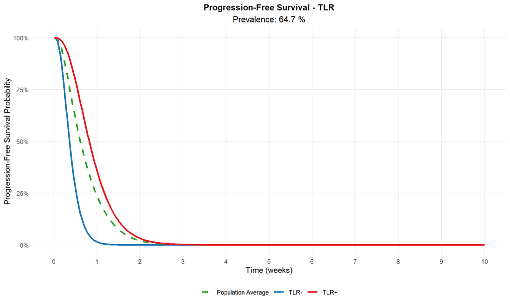

Figure 12: Biomarker-specific survival curves

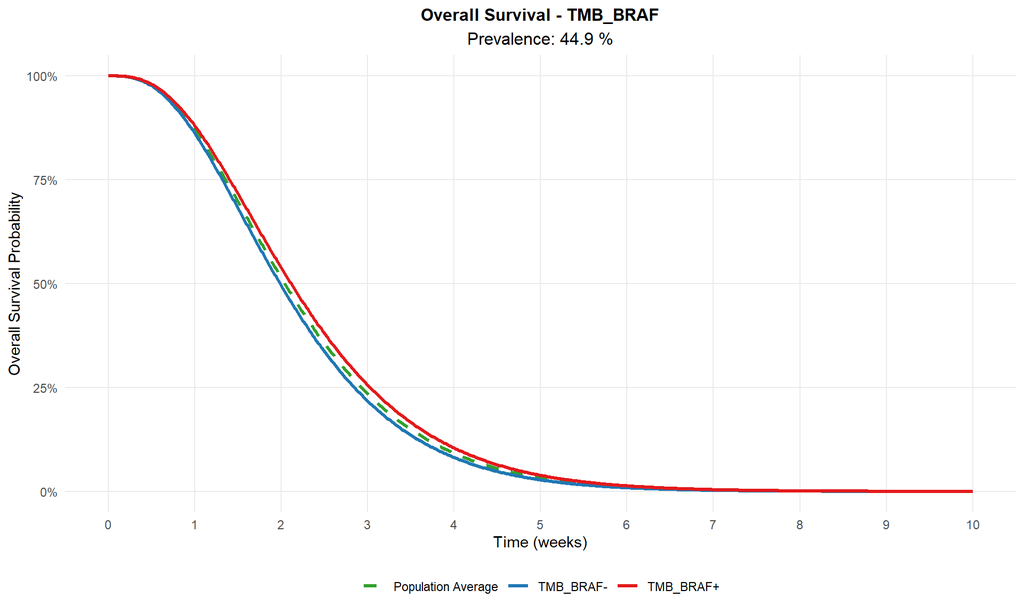

Figure 13: Biomarker-specific survival curves

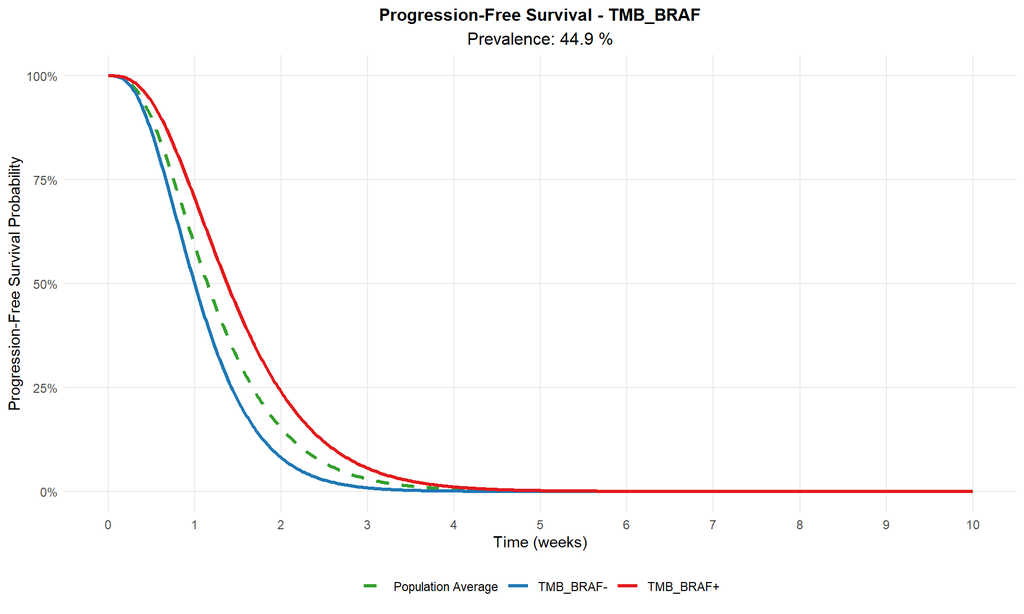

Figure 14: Biomarker-specific survival curves

```r
if (exists("predictions") && exists("strategies_df") && exists("time_points")) {

  # Source plotting functions
  setwd("../../..")
  source("scripts/R/functions/survival_plots.R")

  # Generate plots for each biomarker
  biomarkers <- strategies_df$id[strategies_df$id != "control"]

  for (biomarker in biomarkers) {

    cat("\n\n## ", toupper(biomarker), " Biomarker Results\n\n")

    # OS plot
    os_plot <- plot_biomarker_survival(
      predictions = predictions,
      biomarker_name = biomarker,
      outcome_type = "OS",
      time_points = time_points
    )

    if (!is.null(os_plot)) {
      os_plot <- os_plot +
        labs(title = paste("Overall Survival -", toupper(biomarker))) +
        theme(plot.title = element_text(size = 12, face = "bold"))
      print(os_plot)
    }

    # PFS plot
    pfs_plot <- plot_biomarker_survival(
      predictions = predictions,
      biomarker_name = biomarker,
      outcome_type = "PFS",
      time_points = time_points
    )

    if (!is.null(pfs_plot)) {
      pfs_plot <- pfs_plot +
        labs(title = paste("Progression-Free Survival -", toupper(biomarker))) +
        theme(plot.title = element_text(size = 12, face = "bold"))
      print(pfs_plot)
    }
  }
}
```

# 7 Model Validation and Goodness of Fit

```r
if (exists("models")) {
  cat("### Key Model Performance Metrics\n\n")
  cat("- **AIC-based selection**: Optimal balance between model fit and complexity\n")
  cat("- **Confidence intervals**: 95% confidence bands shown for uncertainty quantification\n")
  cat("- **Biomarker stratification**: Models account for biomarker-specific survival patterns\n")
  cat("- **Population predictions**: Based on modal categories and mean age from complete cases\n\n")

  cat("### Clinical Interpretation\n\n")
  cat("The parametric survival models provide essential inputs for the health economic model by:\n\n")
  cat("1. **Extrapolating beyond trial follow-up**: Parametric distributions allow prediction of long-term survival\n")
  cat("2. **Biomarker-specific predictions**: Different survival patterns for biomarker-positive vs negative patients\n")
  cat("3. **Uncertainty quantification**: Confidence intervals support probabilistic sensitivity analysis\n")
  cat("4. **Clinical plausibility**: Model selection considers both statistical fit and clinical reasonableness\n")
}
```

```
### Key Model Performance Metrics

- **AIC-based selection**: Optimal balance between model fit and complexity
- **Confidence intervals**: 95% confidence bands shown for uncertainty quantification
- **Biomarker stratification**: Models account for biomarker-specific survival patterns
- **Population predictions**: Based on modal categories and mean age from complete cases

### Clinical Interpretation

The parametric survival models provide essential inputs for the health economic model by:

1. **Extrapolating beyond trial follow-up**: Parametric distributions allow prediction of long-term survival
2. **Biomarker-specific predictions**: Different survival patterns for biomarker-positive vs negative patients
3. **Uncertainty quantification**: Confidence intervals support probabilistic sensitivity analysis
4. **Clinical plausibility**: Model selection considers both statistical fit and clinical reasonableness
```

# 8 Technical Notes

## 8.1 Model Fitting Approach

- **Distributions tested**: Exponential, Weibull, Gompertz, Log-logistic, Log-normal, Generalized Gamma
- **Covariate structures**: Full models (age, sex, treatment, biomarkers) vs simplified (biomarkers only)
- **Selection criterion**: AIC preferred over BIC for predictive modeling applications
- **Validation**: Visual comparison with Kaplan-Meier curves and clinical plausibility assessment

## 8.2 Data Considerations

- **Complete case analysis**: Only patients with complete covariate data included
- **Reference patient**: Modal categories for categorical variables, mean for continuous variables
- **Time horizon**: Models fitted to observed follow-up period with extrapolation capability
- **Biomarker prevalences**: Reflect real-world patient population characteristics

**Report completed on:** 2025-10-08  
**Repository:** ben-geisler/METIMMOX-1  
**Report version:** 1.0